# 🔧 Data Preprocessing

## Введение

Этот блок отвечает за предобработку сырых CSV-таблиц, полученных из публичного датасета Olist.  
Включает в себя:

- первичную очистку и стандартизацию колонок,
- обработку пропусков и дубликатов,
- извлечение типовой информации о признаках,
- первичный анализ ключей,
- подготовку к последующей загрузке в Supabase (PostgreSQL).

```python
import pandas as pd
import missingno as msno
import os
import re
import warnings  # Отключение предупреждений
from tabulate import tabulate
import pandas as pd
import matplotlib.pyplot as plt
import seaborn as sns
import numpy as np
import json
warnings.filterwarnings('ignore')  # Отключаем предупреждения
```

## 1. 🗂️ Загрузка и изучение CSV-файлов

**Используется скрипт `load_and_inspect`**

- Поиск всех `.csv` файлов в указанной директории.
- Стандартизация имён колонок (`to_snake_case()`).
- Автоматическое преобразование дат (`convert_dates()`).
- Удаление полных дубликатов.
- Поиск потенциальных первичных ключей и очистка по ним.
- Классификация колонок: даты, текст, числа.
- Генерация отчёта о пропусках (`missing_report`).

📌 *Цель: подготовить корректные датафреймы для дальнейшей загрузки и анализа.*

### Выполним загрузку и начальную предобработки наших данных.

```python
# Применяем функцию.
from src.data_loader import load_and_inspect
dfs = load_and_inspect(folder_path='datasets')
```

```
📦 Загружается: category_name.csv → `category_name`
➡️ Размер: 71 строк × 2 колонок
🔁 Полных дубликатов: 0
✅ Пропусков нет
📅 Дата-признаки: []
📝 Текстовые: ['product_category_name', 'product_category_name_english']
🔢 Числовые: []
🔑 Возможный первичный ключ: product_category_name
✅ Дубликатов по ключу `product_category_name` не выявлено.
=============================================================================================================================

📦 Загружается: closed_deals.csv → `closed_deals`
➡️ Размер: 842 строк × 14 колонок
🔁 Полных дубликатов: 0
⚠️ Пропуски в колонках (%)
has_company                      92.52
has_gtin                         92.40
average_stock                    92.16
declared_product_catalog_size    91.81
lead_behaviour_profile           21.02
business_type                     1.19
lead_type                         0.71
business_segment                  0.12
📅 Дата-признаки: ['won_date']
📝 Текстовые: ['mql_id', 'seller_id', 'sdr_id'] ...
🔢 Числовые: ['declared_product_catalog_size', 'declared_monthly_revenue']
🔑 Возможный первичный ключ: mql_id
✅ Дубликатов по ключу `mql_id` не выявлено.
=============================================================================================================================

📦 Загружается: customers.csv → `customers`
➡️ Размер: 99441 строк × 5 колонок
🔁 Полных дубликатов: 0
✅ Пропусков нет
📅 Дата-признаки: []
📝 Текстовые: ['customer_id', 'customer_unique_id', 'customer_city'] ...
🔢 Числовые: ['customer_zip_code_prefix']
🔑 Возможный первичный ключ: customer_id
✅ Дубликатов по ключу `customer_id` не выявлено.
=============================================================================================================================
```

[output cut: 100 more lines]

```
🔹 geolocation
🔹 marketing_qualified
🔹 orders
🔹 order_items
🔹 order_payments
🔹 order_reviews
🔹 products
🔹 sellers

🧹 Таблицы с пропусками:
🔸 closed_deals: has_company, has_gtin, average_stock, declared_product_catalog_size, lead_behaviour_profile, business_type, lead_type, business_segment
🔸 marketing_qualified: origin
🔸 orders: order_delivered_customer_date, order_delivered_carrier_date, order_approved_at
🔸 order_reviews: review_comment_title, review_comment_message
🔸 products: product_category_name, product_name_lenght, product_description_lenght, product_photos_qty, product_weight_g, product_length_cm, product_height_cm, product_width_cm
```

### Посмотрим на случайные строки наших данных.

```python
# Проходим по словарю dfs и выводим 5 случайных строк для каждого датафрейма
for table_name, df in dfs.items():
    print(f" Пример случайных строк для таблицы: {table_name}")
    display(df.sample(n=3, random_state=42).T)  # random_state для воспроизводимости
    print("=" * 125)
```

```
 Пример случайных строк для таблицы: category_name
```

|  | 22 | 0 | 49 |
| --- | --- | --- | --- |
| product_category_name | cool_stuff | beleza_saude | construcao_ferramentas_seguranca |
| product_category_name_english | cool_stuff | health_beauty | construction_tools_safety |

```
=============================================================================================================================
 Пример случайных строк для таблицы: closed_deals
```

|  | 493 | 215 | 622 |
| --- | --- | --- | --- |
| mql_id | 7290c4082936311a3295b7c9ca7bda8f | e9dcae4d924ac8fff2334db6e5b99482 | 6fec8c1ba9b9aa79bd26e09fc8aae3eb |
| seller_id | 9c1c0c36cd23c20897e473901a8fb149 | 51fdd5d43db628fada4588f89aba3e8e | 603bb4eeb3f0927e59e253357a9ca06b |
| sdr_id | 9e4d1098a3b0f5da39b0bc48f9876645 | 9d12ef1a7eca3ec58c545c678af7869c | 9e4d1098a3b0f5da39b0bc48f9876645 |
| sr_id | fbf4aef3f6915dc0c3c97d6812522f6a | de63de0d10a6012430098db33c679b0b | 85fc447d336637ba1df43e793199fbc8 |
| won_date | 2018-03-19 20:26:27 | 2018-04-11 20:19:49 | 2018-03-29 13:49:44 |
| business_segment | food_drink | car_accessories | handcrafted |
| lead_type | online_medium | offline | offline |
| lead_behaviour_profile | cat | cat | cat |
| has_company | NaN | NaN | NaN |
| has_gtin | NaN | NaN | NaN |
| average_stock | NaN | NaN | NaN |
| business_type | reseller | reseller | manufacturer |
| declared_product_catalog_size | NaN | NaN | NaN |
| declared_monthly_revenue | 0.0 | 0.0 | 0.0 |

```
=============================================================================================================================
 Пример случайных строк для таблицы: customers
```

|  | 52263 | 46645 | 37546 |
| --- | --- | --- | --- |
| customer_id | c7432c6d237ffd6aa36a007b4237ec38 | 7f399d641e2e2064470145178c9e8778 | ba5642b730704dc0f74b7cf715b41ed5 |
| customer_unique_id | 9a897ea48bf988012c00b802f1104a92 | 90436a67885a57f147fb79e6d0e4bc1c | 4d8056f71519ae1069e6747c63c676f7 |
| customer_zip_code_prefix | 2971 | 38610 | 88820 |
| customer_city | sao paulo | unai | icara |
| customer_state | SP | MG | SC |

```
=============================================================================================================================
 Пример случайных строк для таблицы: geolocation
```

|  | 385650 | 610472 | 909557 |
| --- | --- | --- | --- |
| geolocation_zip_code_prefix | 18120 | 36038 | 88330 |
| geolocation_lat | -23.451913 | -21.777914 | -26.995883 |
| geolocation_lng | -47.204391 | -43.388633 | -48.62775 |
| geolocation_city | mairinque | juiz de fora | balneario camboriu |
| geolocation_state | SP | MG | SC |

```
=============================================================================================================================
 Пример случайных строк для таблицы: marketing_qualified
```

|  | 2215 | 2582 | 1662 |
| --- | --- | --- | --- |
| mql_id | 667f061b738858573caad66f5cc56b32 | f89b10e626692ac7a87c19d69f261db2 | d7e7bd5df3a07138eb7cb500f01f89fe |
| first_contact_date | 2018-01-31 00:00:00 | 2018-03-06 00:00:00 | 2017-11-01 00:00:00 |
| landing_page_id | a7982125ff7aa3b2054c6e44f9d28522 | ce1a65abd0973638f1c887a6efcfa82d | 21a104c3279681d9856b8a48723c4fee |
| origin | organic_search | paid_search | paid_search |

```
=============================================================================================================================
 Пример случайных строк для таблицы: orders
```

|  | 52263 | 46645 | 37546 |
| --- | --- | --- | --- |
| order_id | b9a6c5f5df52c7226ac85aee7524c27f | 261e71d2349c713eafa9f3df5972b95d | 67b50899f52995848c427e361e10dde3 |
| customer_id | f160aaf480efdfa7268f0fa535f73e76 | d6708bbbd2d419475869a84e41f620a1 | 1b353c00c71689afba44554e43cc5a76 |
| order_status | delivered | delivered | delivered |
| order_purchase_timestamp | 2018-06-12 20:07:44 | 2018-01-20 12:15:57 | 2018-06-16 21:24:10 |
| order_approved_at | 2018-06-12 20:44:26 | 2018-01-20 12:37:13 | 2018-06-16 21:36:59 |
| order_delivered_carrier_date | 2018-06-13 13:09:00 | 2018-01-25 21:42:52 | 2018-06-21 13:55:00 |
| order_delivered_customer_date | 2018-06-19 12:44:08 | 2018-01-30 11:32:35 | 2018-06-27 13:17:27 |
| order_estimated_delivery_date | 2018-07-17 00:00:00 | 2018-02-15 00:00:00 | 2018-07-16 00:00:00 |

```
=============================================================================================================================
 Пример случайных строк для таблицы: order_items
```

|  | 107777 | 2391 | 77829 |
| --- | --- | --- | --- |
| order_id | f4ee4273538924bda6212f5948e80fde | 056349f85a73d794119c4286c95a52de | b124967afcc82ef17ec41020fe2a9136 |
| order_item_id | 1 | 1 | 1 |
| product_id | 69455f41626a745aea9ee9164cb9eafd | af35be35db4ad0dc288b571453337376 | 12e6d0f655986ceff00c74658dec97b1 |
| seller_id | 7d13fca15225358621be4086e1eb0964 | d20b021d3efdf267a402c402a48ea64b | 3be634553519fb6536a03e1358e9fdc7 |
| shipping_limit_date | 2018-06-19 09:18:15 | 2017-03-09 14:35:09 | 2018-06-06 17:18:09 |
| price | 180.0 | 10.99 | 49.99 |
| freight_value | 20.45 | 16.05 | 8.88 |

```
=============================================================================================================================
 Пример случайных строк для таблицы: order_payments
```

|  | 21856 | 82913 | 81375 |
| --- | --- | --- | --- |
| order_id | 61c7b1cf28b58654fe411aaf87fe249d | a01f943f4a95572159f0603bd160d67a | 267968a4442f2e55c2904cac31c26660 |
| payment_sequential | 1 | 1 | 1 |
| payment_type | debit_card | credit_card | credit_card |
| payment_installments | 1 | 1 | 1 |
| payment_value | 39.6 | 111.42 | 37.37 |

```
=============================================================================================================================
 Пример случайных строк для таблицы: order_reviews
```

|  | 90252 | 24436 | 11313 |
| --- | --- | --- | --- |
| review_id | 406e32984dd5273582105460a79571af | 3bca8d9922bed47eb96f23d121945290 | 65895b807ac5dfe062c82400b3f210b8 |
| order_id | e00ed9d20c3479f9f0e9727ca9d60946 | 3b5351f5f99b46339212291661a9d226 | f395e98fb5c1c6ce1306e80de2fe125b |
| review_score | 5 | 5 | 4 |
| review_comment_title | NaN | NaN | NaN |
| review_comment_message | NaN | Cumpriu o acordado! | NaN |
| review_creation_date | 2017-12-22 00:00:00 | 2018-04-10 00:00:00 | 2017-04-20 00:00:00 |
| review_answer_timestamp | 2017-12-22 21:10:19 | 2018-04-13 01:57:05 | 2017-04-21 11:31:32 |

```
=============================================================================================================================
 Пример случайных строк для таблицы: products
```

|  | 24880 | 6366 | 4989 |
| --- | --- | --- | --- |
| product_id | f819f0c84a64f02d3a5606ca95edd272 | b9de40e43fccb6ba53b7eadbd5c49077 | 26afe4ed5890d941fcba14205863eec7 |
| product_category_name | relogios_presentes | utilidades_domesticas | moveis_decoracao |
| product_name_lenght | 59.0 | 41.0 | 47.0 |
| product_description_lenght | 452.0 | 1188.0 | 1092.0 |
| product_photos_qty | 1.0 | 3.0 | 1.0 |
| product_weight_g | 710.0 | 700.0 | 3850.0 |
| product_length_cm | 19.0 | 70.0 | 30.0 |
| product_height_cm | 13.0 | 10.0 | 30.0 |
| product_width_cm | 14.0 | 15.0 | 30.0 |

```
=============================================================================================================================
 Пример случайных строк для таблицы: sellers
```

|  | 1947 | 1309 | 1606 |
| --- | --- | --- | --- |
| seller_id | 1f7fd2a6fcd5a6fa5d8a4dabc72aaae0 | 6e1862e15f33d9994bc25922a85e1efc | e628d4a53c109f09ca88098338b3a3f5 |
| seller_zip_code_prefix | 95800 | 13505 | 30170 |
| seller_city | venancio aires | rio claro | belo horizonte |
| seller_state | RS | SP | MG |

## Обработка пропусков и аномалий

Принятие решений по каждой таблице с учетом анализа пропусков:

Применение более продвинутых техник для числовых и категориальных данных, таких как заполнение медианой для числовых данных с сильной асимметрией или модой для категориальных.

Оставление пропусков в специфичных случаях и создание бинарных индикаторов для отсутствующих значений.

📌 Цель: обеспечить корректную логику при загрузке данных в базу, учитывать возможную бизнес-интерпретацию пропусков и аномалий, а также предоставить рекомендации по обработке для каждого признака.

### Датафрейм `closed_deals`

```python
# Применим функцию для изучения пропусков
from src.analyze_missing import analyze_missing
analyze_missing(dfs, "closed_deals")
```

```
📋 Рекомендации по пропускам для датафрейма: 'closed_deals'

Колонка                          % Пропусков  Тип      Рекомендация            Обоснование
-----------------------------  -------------  -------  ----------------------  ------------------------------
business_segment                         0.1  object   🔄 Заполнить 'unknown'  Категориальный признак
lead_type                                0.7  object   🔄 Заполнить 'unknown'  Категориальный признак
lead_behaviour_profile                  21.0  object   🔄 Заполнить 'unknown'  Категориальный признак
has_company                             92.5  object   🔥 Удалить колонку      Слишком много пропусков (>90%)
has_gtin                                92.4  object   🔥 Удалить колонку      Слишком много пропусков (>90%)
average_stock                           92.2  object   🔥 Удалить колонку      Слишком много пропусков (>90%)
business_type                            1.2  object   🔄 Заполнить 'unknown'  Категориальный признак
declared_product_catalog_size           91.8  float64  🔥 Удалить колонку      Слишком много пропусков (>90%)

💡 Генерация кода для применения:

# business_segment:
dfs['closed_deals']['business_segment'] = dfs['closed_deals']['business_segment'].fillna('unknown')

# lead_type:
dfs['closed_deals']['lead_type'] = dfs['closed_deals']['lead_type'].fillna('unknown')

# lead_behaviour_profile:
dfs['closed_deals']['lead_behaviour_profile'] = dfs['closed_deals']['lead_behaviour_profile'].fillna('unknown')

# has_company:
dfs['closed_deals'].drop(columns=['has_company'], inplace=True)

# has_gtin:
dfs['closed_deals'].drop(columns=['has_gtin'], inplace=True)

# average_stock:
dfs['closed_deals'].drop(columns=['average_stock'], inplace=True)

# business_type:
dfs['closed_deals']['business_type'] = dfs['closed_deals']['business_type'].fillna('unknown')

# declared_product_catalog_size:
dfs['closed_deals'].drop(columns=['declared_product_catalog_size'], inplace=True)


🔗 Корреляции между пропусками:

Колонка 1                      Колонка 2                        Корреляция  Рекомендация
-----------------------------  -----------------------------  ------------  ----------------------------------------
has_gtin                       has_company                            0.96  🎯 Сильно связаны — оставить только одну
has_company                    average_stock                          0.87  📦 Добавить флаг 'оба пропущены'
has_gtin                       average_stock                          0.85  📦 Добавить флаг 'оба пропущены'
declared_product_catalog_size  average_stock                          0.7   📦 Добавить флаг 'оба пропущены'
has_company                    declared_product_catalog_size          0.67  🧩 Умеренная связь
has_gtin                       declared_product_catalog_size          0.68  🧩 Умеренная связь
```

📌 Решения:

```python
# business_segment:
dfs['closed_deals']['business_segment'] = dfs['closed_deals']['business_segment'].fillna('home_decor')

# lead_type:
dfs['closed_deals']['lead_type'] = dfs['closed_deals']['lead_type'].fillna('online_medium')

# lead_behaviour_profile:
dfs['closed_deals']['lead_behaviour_profile'] = dfs['closed_deals']['lead_behaviour_profile'].fillna('cat')

# has_company:
#dfs['closed_deals'].drop(columns=['has_company'], inplace=True)

# has_gtin:
#dfs['closed_deals'].drop(columns=['has_gtin'], inplace=True)

# average_stock:
dfs['closed_deals'].drop(columns=['average_stock'], inplace=True)

# business_type:
dfs['closed_deals']['business_type'] = dfs['closed_deals']['business_type'].fillna('reseller')

# declared_product_catalog_size:
#dfs['closed_deals'].drop(columns=['declared_product_catalog_size'], inplace=True)
print(f"Пропусков осталось {dfs['closed_deals'].isna().sum().sum()}")
```

```
Пропусков осталось 2330
```

### Таблица: `marketing_qualified`

```python
# Применим функцию для изучения пропусков
analyze_missing(dfs, "marketing_qualified")
```

```
📋 Рекомендации по пропускам для датафрейма: 'marketing_qualified'

Колонка      % Пропусков  Тип     Рекомендация            Обоснование
---------  -------------  ------  ----------------------  ----------------------
origin               0.8  object  🔄 Заполнить 'unknown'  Категориальный признак

💡 Генерация кода для применения:

# origin:
dfs['marketing_qualified']['origin'] = dfs['marketing_qualified']['origin'].fillna('unknown')


✅ Явных корреляций между пропусками не найдено.
```

📌 Решения::

- origin.fillna('unknown') — безопасно, не искажает распределение.

```python
# Работаем напрямую с копией внутри словаря
dfs['marketing_qualified']['origin'] = dfs['marketing_qualified']['origin'].fillna('unknown')
print(f"Пропусков осталось {dfs['marketing_qualified'].isna().sum().sum()}")
```

```
Пропусков осталось 0
```

### Таблица: `orders`

```python
# Применим функцию для изучения пропусков
analyze_missing(dfs, "orders")
```

```
📋 Рекомендации по пропускам для датафрейма: 'orders'

Колонка                          % Пропусков  Тип             Рекомендация             Обоснование
-----------------------------  -------------  --------------  -----------------------  ----------------------
order_approved_at                        0.2  object          🔄 Заполнить 'unknown'   Категориальный признак
order_delivered_carrier_date             1.8  datetime64[ns]  🕒 Заполнить ближайшими  Длинный временной ряд
order_delivered_customer_date            3.0  datetime64[ns]  🕒 Заполнить ближайшими  Длинный временной ряд

💡 Генерация кода для применения:

# order_approved_at:
dfs['orders']['order_approved_at'] = dfs['orders']['order_approved_at'].fillna('unknown')

# order_delivered_carrier_date:
dfs['orders']['order_delivered_carrier_date'] = dfs['orders']['order_delivered_carrier_date'].fillna(method='ffill').fillna(method='bfill')

# order_delivered_customer_date:
dfs['orders']['order_delivered_customer_date'] = dfs['orders']['order_delivered_customer_date'].fillna(method='ffill').fillna(method='bfill')


🔗 Корреляции между пропусками:

Колонка 1                      Колонка 2                       Корреляция  Рекомендация
-----------------------------  ----------------------------  ------------  --------------------------------
order_delivered_customer_date  order_delivered_carrier_date          0.77  📦 Добавить флаг 'оба пропущены'
```

📌 Решения:

- Оставляем как есть, пропуски связаны со статусом заказа.

### Таблица: `order_reviews`

```python
# Применим функцию для изучения пропусков
analyze_missing(dfs, "order_reviews")
print(f"Пропусков осталось {dfs['order_reviews'].isna().sum().sum()}")
```

```
📋 Рекомендации по пропускам для датафрейма: 'order_reviews'

Колонка                   % Пропусков  Тип     Рекомендация            Обоснование
----------------------  -------------  ------  ----------------------  ----------------------
review_comment_title             88.3  object  🔄 Заполнить 'unknown'  Категориальный признак
review_comment_message           58.7  object  🔄 Заполнить 'unknown'  Категориальный признак

💡 Генерация кода для применения:

# review_comment_title:
dfs['order_reviews']['review_comment_title'] = dfs['order_reviews']['review_comment_title'].fillna('unknown')

# review_comment_message:
dfs['order_reviews']['review_comment_message'] = dfs['order_reviews']['review_comment_message'].fillna('unknown')


✅ Явных корреляций между пропусками не найдено.
Пропусков осталось 145903
```

📌 Решения:

- Необязательный поля — заполним на "unknown".

```python
# review_comment_title:
dfs['order_reviews']['review_comment_title'] = dfs['order_reviews']['review_comment_title'].fillna('unknown')

# review_comment_message:
dfs['order_reviews']['review_comment_message'] = dfs['order_reviews']['review_comment_message'].fillna('unknown')
```

### Таблица: `products`

```python
analyze_missing(dfs, "products")
```

```
📋 Рекомендации по пропускам для датафрейма: 'products'

Колонка                       % Пропусков  Тип      Рекомендация            Обоснование
--------------------------  -------------  -------  ----------------------  --------------------------------------------
product_category_name                 1.9  object   🔄 Заполнить 'unknown'  Категориальный признак
product_name_lenght                   1.9  float64  🟢 Заполнить средним    Числовой признак с нормальным распределением
product_description_lenght            1.9  float64  🟢 Заполнить средним    Числовой признак с нормальным распределением
product_photos_qty                    1.9  float64  🟡 Заполнить медианой   Числовой признак с асимметрией
product_weight_g                      0.0  float64  🟡 Заполнить медианой   Числовой признак с асимметрией
product_length_cm                     0.0  float64  🟢 Заполнить средним    Числовой признак с нормальным распределением
product_height_cm                     0.0  float64  🟡 Заполнить медианой   Числовой признак с асимметрией
product_width_cm                      0.0  float64  🟢 Заполнить средним    Числовой признак с нормальным распределением

💡 Генерация кода для применения:

# product_category_name:
dfs['products']['product_category_name'] = dfs['products']['product_category_name'].fillna('unknown')

# product_name_lenght:
dfs['products']['product_name_lenght'] = dfs['products']['product_name_lenght'].fillna(48.48)

# product_description_lenght:
dfs['products']['product_description_lenght'] = dfs['products']['product_description_lenght'].fillna(771.50)

# product_photos_qty:
dfs['products']['product_photos_qty'] = dfs['products']['product_photos_qty'].fillna(1.00)

# product_weight_g:
dfs['products']['product_weight_g'] = dfs['products']['product_weight_g'].fillna(700.00)

# product_length_cm:
dfs['products']['product_length_cm'] = dfs['products']['product_length_cm'].fillna(30.82)

# product_height_cm:
dfs['products']['product_height_cm'] = dfs['products']['product_height_cm'].fillna(13.00)

# product_width_cm:
dfs['products']['product_width_cm'] = dfs['products']['product_width_cm'].fillna(23.20)


🔗 Корреляции между пропусками:

Колонка 1                   Колонка 2                     Корреляция  Рекомендация
--------------------------  --------------------------  ------------  ----------------------------------------
product_name_lenght         product_category_name                  1  🎯 Сильно связаны — оставить только одну
product_description_lenght  product_category_name                  1  🎯 Сильно связаны — оставить только одну
product_photos_qty          product_category_name                  1  🎯 Сильно связаны — оставить только одну
product_photos_qty          product_name_lenght                    1  🎯 Сильно связаны — оставить только одну
product_name_lenght         product_description_lenght             1  🎯 Сильно связаны — оставить только одну
product_photos_qty          product_description_lenght             1  🎯 Сильно связаны — оставить только одну
product_width_cm            product_weight_g                       1  🎯 Сильно связаны — оставить только одну
product_weight_g            product_length_cm                      1  🎯 Сильно связаны — оставить только одну
product_width_cm            product_length_cm                      1  🎯 Сильно связаны — оставить только одну
product_weight_g            product_height_cm                      1  🎯 Сильно связаны — оставить только одну
product_length_cm           product_height_cm                      1  🎯 Сильно связаны — оставить только одну
product_width_cm            product_height_cm                      1  🎯 Сильно связаны — оставить только одну
```

📌 Решения:

- Малые пропуски (0.006%) — заменить медианой по product_category_name.
- Пропуски в product_category_name можно заменить на 'unknown'.
- Длины названия/описания — либо оставить, либо пересчитать при наличии product_name, product_description.

```python
# Работаем напрямую с копией внутри словаря
dfs['products'] = dfs['products'].copy()

# product_category_name: NaN → 'unknown'
dfs['products']['product_category_name'] = dfs['products']['product_category_name'].fillna('unknown')

# Заполнение product_name_lenght медианой
dfs['products']['product_name_lenght'] = dfs['products']['product_name_lenght'].fillna(
    dfs['products']['product_name_lenght'].median()
)

# Заполнение product_description_lenght медианой
dfs['products']['product_description_lenght'] = dfs['products']['product_description_lenght'].fillna(
    dfs['products']['product_description_lenght'].median()
)

# product_photos_qty: пропуски → 0
dfs['products']['product_photos_qty'] = dfs['products']['product_photos_qty'].fillna(0).astype(int)

# Заполнение размеров и веса медианой в категории
dim_cols = ['product_weight_g', 'product_length_cm', 'product_height_cm', 'product_width_cm']
for col in dim_cols:
    dfs['products'][col] = dfs['products'].groupby('product_category_name')[col]\
                                          .transform(lambda x: x.fillna(x.median()))
print(f"Пропусков осталось {dfs['products'].isna().sum().sum()}")
```

```
Пропусков осталось 0
```

## Приведение типов и стандартизация

- Проверка и явное преобразование типов:
  - `datetime` для всех дат.
  - `int/float` для числовых значений (`payment_value`, `price`, и т.д.).
  - `category` для фиксированных наборов (например, `product_category_name`).
- Явная типизация для логических признаков (`is_delivered`, `has_comment`, и т.п.).

📌 *Цель: оптимизация памяти и подготовка к загрузке СУБД.*

### Оптимизируем типы танных.

```python
# Применение функции
from src.optimize_data_types import optimize_data_type

# Зададим словарь для принудительного приведения типов по окончанию
dtype_rules = {'_id': 'str',
               '_at': 'datetime',
               '_city': 'category',
               '_title':'str',
               '_message':'str',
               '_gtin':'bool',
               '_company':'bool'}

# Применим скрипт
dfso, reports = optimize_data_type(dfs, dtype_rules=dtype_rules, verbose=True)
```

```
📊 Отчет оптимизации для: category_name

ℹ️ Изменений типов данных не обнаружено

💾 Статистика использования памяти:
-----------------------  -------------
Исходный размер          0.01 MB
Оптимизированный размер  0.01 MB
Экономия памяти          0.00 MB(0.0%)
-----------------------  -------------

📈 Общая статистика:
• Колонок: 2
• Строк: 71
• Оптимизировано колонок: 0
=============================================================================================================================

📊 Отчет оптимизации для: closed_deals

🔀 Изменения типов данных:
Колонка                   Исходный тип    Новый тип
------------------------  --------------  -----------
business_segment          object          category
lead_type                 object          category
lead_behaviour_profile    object          category
has_company               object          bool
has_gtin                  object          bool
business_type             object          category
declared_monthly_revenue  float64         int32

💾 Статистика использования памяти:
-----------------------  --------------
Исходный размер          0.57 MB
Оптимизированный размер  0.31 MB
Экономия памяти          0.26 MB(45.4%)
-----------------------  --------------

📈 Общая статистика:
• Колонок: 13
• Строк: 842
```

[output cut: 190 more lines]

```
seller_city             object          category
seller_state            object          category

💾 Статистика использования памяти:
-----------------------  --------------
Исходный размер          0.66 MB
Оптимизированный размер  0.34 MB
Экономия памяти          0.32 MB(48.3%)
-----------------------  --------------

📈 Общая статистика:
• Колонок: 4
• Строк: 3095
• Оптимизировано колонок: 3
=============================================================================================================================
```

```
🏁 Итоговая экономия памяти по всем датафреймам: 142.94 MB (50.4%)
```

## Локализация данных

📌 *Цель: Для лучшего понимания бизнес процессов.*

Мы предварительно загрузили в нейросеть уникальные названия категорий и выполнили сохранение получившихся словарей в JSON формате.

```python
# Загрузка JSON файлов
with open('translation.json', 'r', encoding='utf-8') as f:
    translation = json.load(f)

# Выводим первые элементы каждого раздела
for dict_name, data in translation.items():
    print(f"\n=== Первые 3 элемента из {dict_name} ===")

    # Преобразуем словарь в список пар (key, value) и берем первые 3 элемента
    first_items = list(data.items())[:3]

    for key, value in first_items:
        print(f"{key}: {value}")
```

```
=== Первые 3 элемента из category_translation_dict ===
health_beauty: красота и здоровье
computers_accessories: компьютеры и аксессуары
auto: авто

=== Первые 3 элемента из category_group_dict ===
health_beauty: красота и здоровье
perfumery: красота и здоровье
computers_accessories: электроника

=== Первые 3 элемента из business_segment_translation ===
home_decor: домашний декор
health_beauty: здоровье и красота
car_accessories: автоаксессуары

=== Первые 3 элемента из lead_type_translation ===
online_medium: онлайн (средний)
online_big: онлайн (крупный)
industry: промышленность

=== Первые 3 элемента из business_type_translation ===
reseller: реселлер
manufacturer: производитель
other: другое

=== Первые 3 элемента из origin_translation ===
organic_search: органика
paid_search: платный поиск
social: социальные сети

=== Первые 3 элемента из order_status_translation ===
delivered: доставлен
shipped: отправлен
canceled: отменен

=== Первые 3 элемента из payment_method_translation ===
credit_card: кредитная карта
voucher: ваучер
boleto: болета
```

```python
# Применение к category_name_translated
dfso['category_name']['category_name_translated'] = (
    dfso['category_name']['product_category_name_english']
    .map(translation["category_translation_dict"])
)

# Применение к category_name_grouped
dfso['category_name']['category_name_grouped'] = (
    dfso['category_name']['product_category_name_english']
    .map(translation["category_group_dict"])
)


# Применим к business_segment
dfso['closed_deals']['business_segment'] = (
    dfso['closed_deals']['business_segment']
    .map(translation['business_segment_translation'])
)

# Применим к lead_type
dfso['closed_deals']['lead_type'] = (
    dfso['closed_deals']['lead_type']
    .map(translation['lead_type_translation'])
)

# Применим к 'business_type'
dfso['closed_deals']['business_type'] = (
    dfso['closed_deals']['business_type']
    .map(translation['business_type_translation'])
)

# Применим к 'origin'
dfso['marketing_qualified']['origin'] = (
    dfso['marketing_qualified']['origin']
    .map(translation['origin_translation'])
)

# Применим к 'order_status'
dfso['orders']['order_status'] = (
    dfso['orders']['order_status']
    .map(translation['order_status_translation'])
)

# Применим к 'payment_type'
dfso['order_payments']['payment_type'] = (
    dfso['order_payments']['payment_type']
    .map(translation['payment_method_translation'])
)


# Объединение данных
dfso['products'] = dfso['products'].merge(
    dfso['category_name'],
    on='product_category_name'
)

# Удаление ненужных колонок
dfso['products'] = dfso['products'].drop(
    columns=['product_category_name']
)

# Удаление временного DataFrame
del dfso['category_name']

# Проверка результата
dfso['products'].sample(5)
```

|  | product_id | product_name_lenght | product_description_lenght | product_photos_qty | product_weight_g | product_length_cm | product_height_cm | product_width_cm | product_category_name_english | category_name_translated | category_name_grouped |
| --- | --- | --- | --- | --- | --- | --- | --- | --- | --- | --- | --- |
| 7065 | 73064dfeb27bf7cc4599c2f842438bad | 32 | 115 | 2 | 900 | 16 | 13 | 13 | housewares | товары для дома | для дома |
| 31424 | e209d220eede88d11b0dd048529e6716 | 52 | 1430 | 8 | 700 | 20 | 50 | 40 | luggage_accessories | багаж | подарки |
| 27340 | ce98361ef1341e15087ae4b1b2c53fdd | 59 | 618 | 2 | 767 | 52 | 6 | 42 | furniture_decor | мебель и декор | для дома |
| 4634 | d88a953f5d1e00cbfb5785dcb8a9f81f | 41 | 547 | 5 | 3100 | 72 | 11 | 13 | toys | игрушки | дети |
| 7100 | 1817be76e48588632c33c4f112a79426 | 50 | 509 | 2 | 283 | 20 | 13 | 20 | watches_gifts | часы и подарки | подарки |

## Исследовательский анализ

### Количественные признаки.

```
============================================================
Анализ числовых признаков в таблице: CLOSED_DEALS
============================================================
```

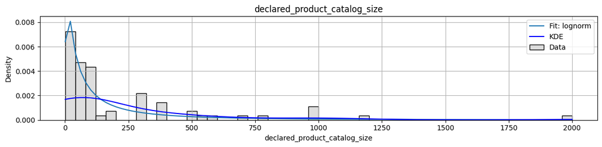

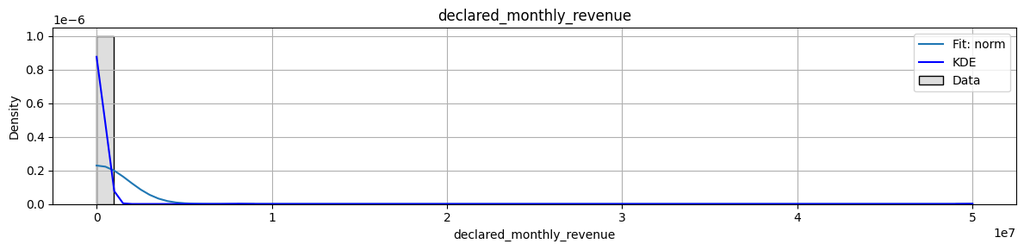

```
╒═══════════════════════════════╤═════════════════╤═══════════════╤═══════════╤═══════════════════════════════════════════════════╕
│ Признак                       │ Распределение   │   Скошенность │   Выбросы │ Комментарии                                       │
╞═══════════════════════════════╪═════════════════╪═══════════════╪═══════════╪═══════════════════════════════════════════════════╡
│ declared_product_catalog_size │ lognorm         │          2.67 │         6 │ Распределение не похоже на нормальное (p ≤ 0.05). │
│                               │                 │               │           │ Обнаружено много выбросов: 6 (8.7%).              │
│                               │                 │               │           │ Сильная скошенность (skew = 2.67).                │
│                               │                 │               │           │ Наилучшее распределение по ММП: lognorm.          │
├───────────────────────────────┼─────────────────┼───────────────┼───────────┼───────────────────────────────────────────────────┤
│ declared_monthly_revenue      │ norm            │         27.99 │        45 │ Распределение не похоже на нормальное (p ≤ 0.05). │
│                               │                 │               │           │ Обнаружено много выбросов: 45 (5.3%).             │
│                               │                 │               │           │ Сильная скошенность (skew = 27.99).               │
│                               │                 │               │           │ Наилучшее распределение по ММП: norm.             │
╘═══════════════════════════════╧═════════════════╧═══════════════╧═══════════╧═══════════════════════════════════════════════════╛

============================================================
marketing_qualified: Нет числовых признаков для анализа
============================================================

============================================================
orders: Нет числовых признаков для анализа
============================================================

============================================================
Анализ числовых признаков в таблице: ORDER_ITEMS
============================================================
```

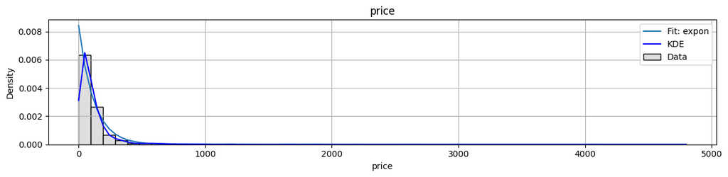

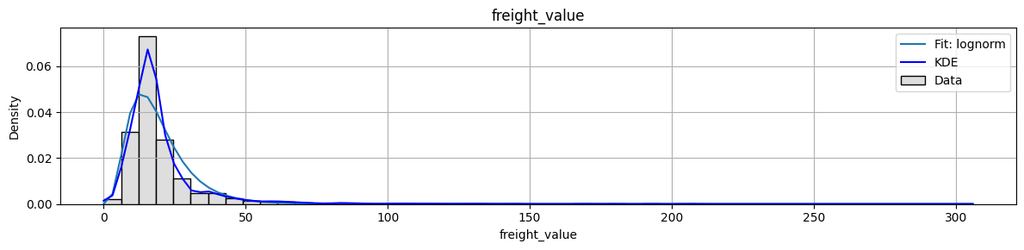

```
╒═══════════════╤═════════════════╤═══════════════╤═══════════╤═══════════════════════════════════════════════════╕
│ Признак       │ Распределение   │   Скошенность │   Выбросы │ Комментарии                                       │
╞═══════════════╪═════════════════╪═══════════════╪═══════════╪═══════════════════════════════════════════════════╡
│ price         │ expon           │          8.33 │       751 │ Распределение не похоже на нормальное (p ≤ 0.05). │
│               │                 │               │           │ Обнаружено много выбросов: 751 (7.5%).            │
│               │                 │               │           │ Сильная скошенность (skew = 8.33).                │
│               │                 │               │           │ Наилучшее распределение по ММП: expon.            │
├───────────────┼─────────────────┼───────────────┼───────────┼───────────────────────────────────────────────────┤
│ freight_value │ lognorm         │          5.01 │      1048 │ Распределение не похоже на нормальное (p ≤ 0.05). │
│               │                 │               │           │ Обнаружено много выбросов: 1048 (10.5%).          │
│               │                 │               │           │ Сильная скошенность (skew = 5.01).                │
│               │                 │               │           │ Наилучшее распределение по ММП: lognorm.          │
╘═══════════════╧═════════════════╧═══════════════╧═══════════╧═══════════════════════════════════════════════════╛

============================================================
Анализ числовых признаков в таблице: ORDER_PAYMENTS
============================================================
```

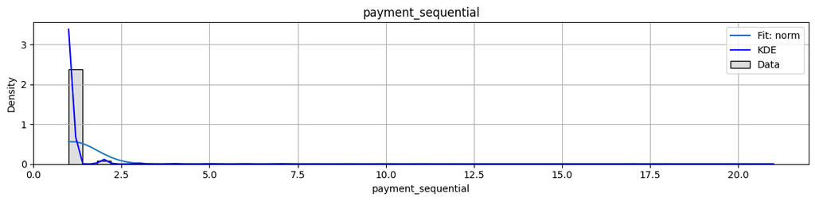

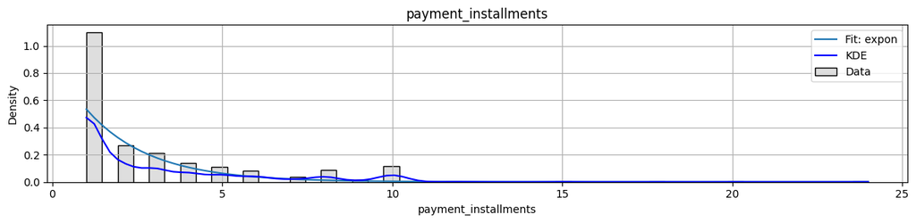

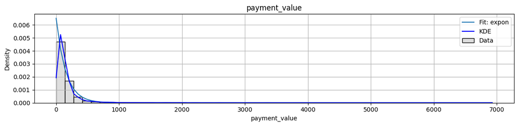

```
╒══════════════════════╤═════════════════╤═══════════════╤═══════════╤═══════════════════════════════════════════════════╕
│ Признак              │ Распределение   │   Скошенность │   Выбросы │ Комментарии                                       │
╞══════════════════════╪═════════════════╪═══════════════╪═══════════╪═══════════════════════════════════════════════════╡
│ payment_sequential   │ norm            │         14.48 │       471 │ Распределение не похоже на нормальное (p ≤ 0.05). │
│                      │                 │               │           │ Количество выбросов незначительно: 471.           │
│                      │                 │               │           │ Сильная скошенность (skew = 14.48).               │
│                      │                 │               │           │ Наилучшее распределение по ММП: norm.             │
├──────────────────────┼─────────────────┼───────────────┼───────────┼───────────────────────────────────────────────────┤
│ payment_installments │ expon           │          1.73 │       635 │ Распределение не похоже на нормальное (p ≤ 0.05). │
│                      │                 │               │           │ Обнаружено много выбросов: 635 (6.3%).            │
│                      │                 │               │           │ Сильная скошенность (skew = 1.73).                │
│                      │                 │               │           │ Наилучшее распределение по ММП: expon.            │
├──────────────────────┼─────────────────┼───────────────┼───────────┼───────────────────────────────────────────────────┤
│ payment_value        │ expon           │          8.32 │       751 │ Распределение не похоже на нормальное (p ≤ 0.05). │
│                      │                 │               │           │ Обнаружено много выбросов: 751 (7.5%).            │
│                      │                 │               │           │ Сильная скошенность (skew = 8.32).                │
│                      │                 │               │           │ Наилучшее распределение по ММП: expon.            │
╘══════════════════════╧═════════════════╧═══════════════╧═══════════╧═══════════════════════════════════════════════════╛

============================================================
Анализ числовых признаков в таблице: ORDER_REVIEWS
============================================================
```

[figure not shown]

```
╒══════════════╤═════════════════╤═══════════════╤═══════════╤═══════════════════════════════════════════════════╕
│ Признак      │ Распределение   │   Скошенность │   Выбросы │ Комментарии                                       │
╞══════════════╪═════════════════╪═══════════════╪═══════════╪═══════════════════════════════════════════════════╡
│ review_score │ beta            │         -1.32 │      1510 │ Распределение не похоже на нормальное (p ≤ 0.05). │
│              │                 │               │           │ Обнаружено много выбросов: 1510 (15.1%).          │
│              │                 │               │           │ Сильная скошенность (skew = -1.32).               │
│              │                 │               │           │ Наилучшее распределение по ММП: beta.             │
╘══════════════╧═════════════════╧═══════════════╧═══════════╧═══════════════════════════════════════════════════╛

============================================================
Анализ числовых признаков в таблице: PRODUCTS
============================================================
```

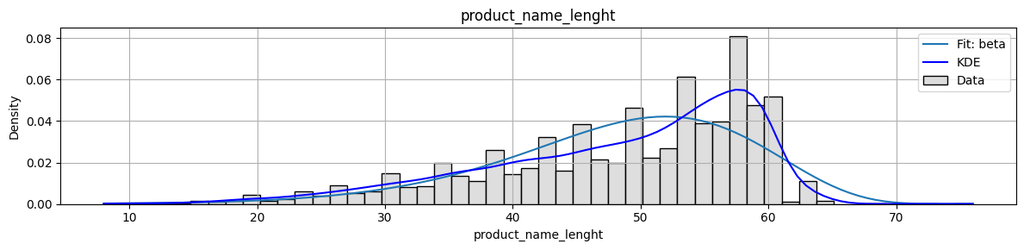

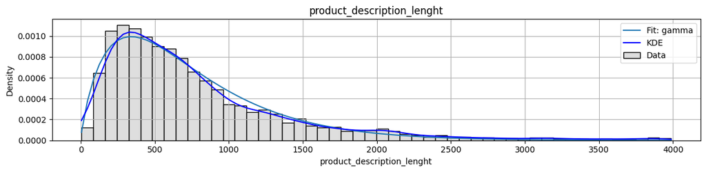

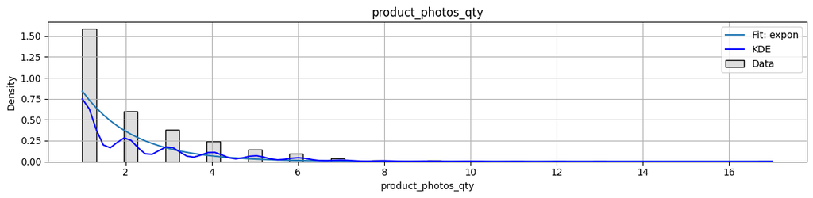

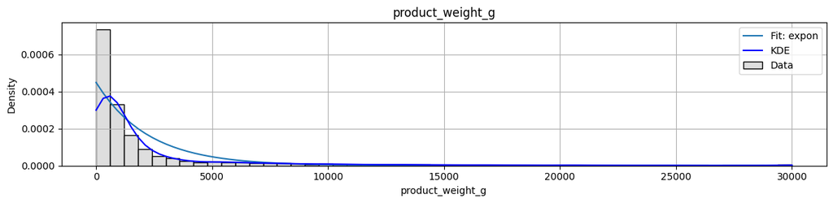

[3 more figures not shown]

```
╒════════════════════════════╤═════════════════╤═══════════════╤═══════════╤═══════════════════════════════════════════════════╕
│ Признак                    │ Распределение   │   Скошенность │   Выбросы │ Комментарии                                       │
╞════════════════════════════╪═════════════════╪═══════════════╪═══════════╪═══════════════════════════════════════════════════╡
│ product_name_lenght        │ beta            │         -0.91 │        96 │ Распределение не похоже на нормальное (p ≤ 0.05). │
│                            │                 │               │           │ Количество выбросов незначительно: 96.            │
│                            │                 │               │           │ Умеренная скошенность (skew = -0.91).             │
│                            │                 │               │           │ Наилучшее распределение по ММП: beta.             │
├────────────────────────────┼─────────────────┼───────────────┼───────────┼───────────────────────────────────────────────────┤
│ product_description_lenght │ gamma           │          1.93 │       643 │ Распределение не похоже на нормальное (p ≤ 0.05). │
│                            │                 │               │           │ Обнаружено много выбросов: 643 (6.4%).            │
│                            │                 │               │           │ Сильная скошенность (skew = 1.93).                │
│                            │                 │               │           │ Наилучшее распределение по ММП: gamma.            │
├────────────────────────────┼─────────────────┼───────────────┼───────────┼───────────────────────────────────────────────────┤
│ product_photos_qty         │ expon           │          2.07 │       251 │ Распределение не похоже на нормальное (p ≤ 0.05). │
│                            │                 │               │           │ Количество выбросов незначительно: 251.           │
│                            │                 │               │           │ Сильная скошенность (skew = 2.07).                │
│                            │                 │               │           │ Наилучшее распределение по ММП: expon.            │
├────────────────────────────┼─────────────────┼───────────────┼───────────┼───────────────────────────────────────────────────┤
│ product_weight_g           │ expon           │          3.63 │      1379 │ Распределение не похоже на нормальное (p ≤ 0.05). │
│                            │                 │               │           │ Обнаружено много выбросов: 1379 (13.8%).          │
│                            │                 │               │           │ Сильная скошенность (skew = 3.63).                │
│                            │                 │               │           │ Наилучшее распределение по ММП: expon.            │
├────────────────────────────┼─────────────────┼───────────────┼───────────┼───────────────────────────────────────────────────┤
│ product_length_cm          │ lognorm         │          1.72 │       438 │ Распределение не похоже на нормальное (p ≤ 0.05). │
│                            │                 │               │           │ Количество выбросов незначительно: 438.           │
│                            │                 │               │           │ Сильная скошенность (skew = 1.72).                │
│                            │                 │               │           │ Наилучшее распределение по ММП: lognorm.          │
├────────────────────────────┼─────────────────┼───────────────┼───────────┼───────────────────────────────────────────────────┤
│ product_height_cm          │ beta            │          2.04 │       550 │ Распределение не похоже на нормальное (p ≤ 0.05). │
│                            │                 │               │           │ Обнаружено много выбросов: 550 (5.5%).            │
│                            │                 │               │           │ Сильная скошенность (skew = 2.04).                │
│                            │                 │               │           │ Наилучшее распределение по ММП: beta.             │
├────────────────────────────┼─────────────────┼───────────────┼───────────┼───────────────────────────────────────────────────┤
│ product_width_cm           │ lognorm         │          1.64 │       276 │ Распределение не похоже на нормальное (p ≤ 0.05). │
│                            │                 │               │           │ Количество выбросов незначительно: 276.           │
│                            │                 │               │           │ Сильная скошенность (skew = 1.64).                │
│                            │                 │               │           │ Наилучшее распределение по ММП: lognorm.          │
╘════════════════════════════╧═════════════════╧═══════════════╧═══════════╧═══════════════════════════════════════════════════╛

✅ Анализ числовых признаков завершен!
```

```python
from src.numeric_features import analyze_numeric_features
analyze_numeric_features(
    df_dict=dfso,
    bins=50,
    max_sample=10000,
    exclude=['customers', 'geolocation', 'sellers']  # список таблиц, которые исключить
)
```

### Категориальные признаки.

```
=============================================================================================================================
Анализ таблицы: CLOSED_DEALS
=============================================================================================================================
```

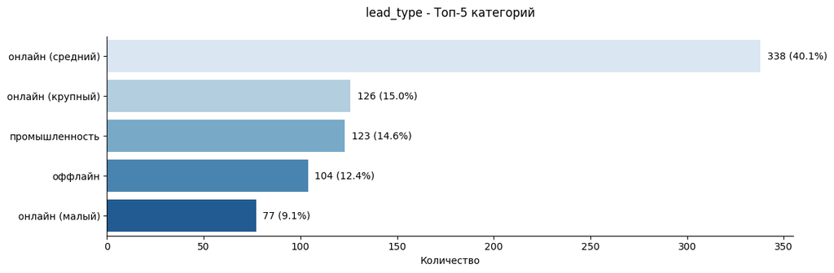

```
+-------------------------+--------------------------+
| Метрика                 | Значение                 |
+=========================+==========================+
| Всего записей:          | 842                      |
+-------------------------+--------------------------+
| Уникальных значений:    | 8                        |
+-------------------------+--------------------------+
| Пропуски:               | 0 (0.0%)                 |
+-------------------------+--------------------------+
| Доминирующая категория: | онлайн (средний) (40.1%) |
+-------------------------+--------------------------+
```

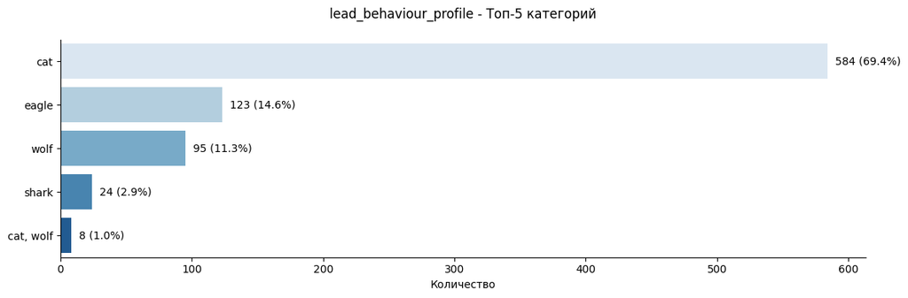

```
+-------------------------+-------------+
| Метрика                 | Значение    |
+=========================+=============+
| Всего записей:          | 842         |
+-------------------------+-------------+
| Уникальных значений:    | 9           |
+-------------------------+-------------+
| Пропуски:               | 0 (0.0%)    |
+-------------------------+-------------+
| Доминирующая категория: | cat (69.4%) |
+-------------------------+-------------+
```

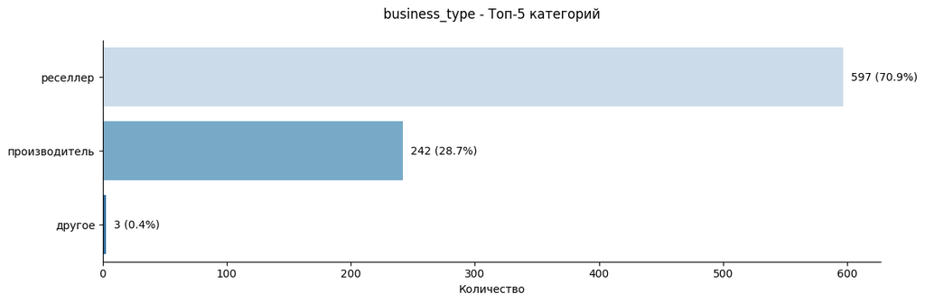

```
+-------------------------+------------------+
| Метрика                 | Значение         |
+=========================+==================+
| Всего записей:          | 842              |
+-------------------------+------------------+
| Уникальных значений:    | 3                |
+-------------------------+------------------+
| Пропуски:               | 0 (0.0%)         |
+-------------------------+------------------+
| Доминирующая категория: | реселлер (70.9%) |
+-------------------------+------------------+


=============================================================================================================================
Анализ таблицы: CUSTOMERS
=============================================================================================================================
```

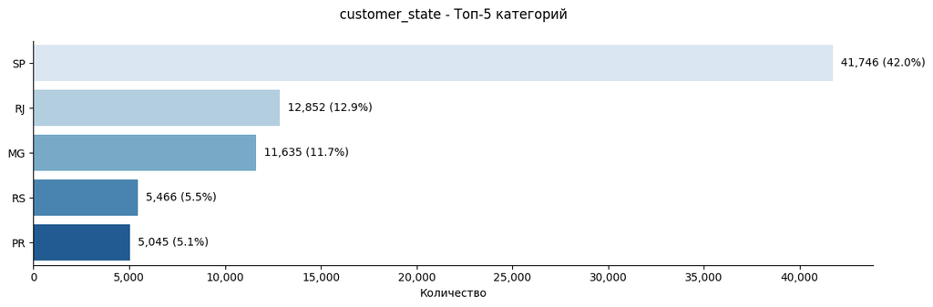

```
+-------------------------+------------+
| Метрика                 | Значение   |
+=========================+============+
| Всего записей:          | 99,441     |
+-------------------------+------------+
| Уникальных значений:    | 27         |
+-------------------------+------------+
| Пропуски:               | 0 (0.0%)   |
+-------------------------+------------+
| Доминирующая категория: | SP (42.0%) |
+-------------------------+------------+


=============================================================================================================================
Анализ таблицы: GEOLOCATION
=============================================================================================================================
```

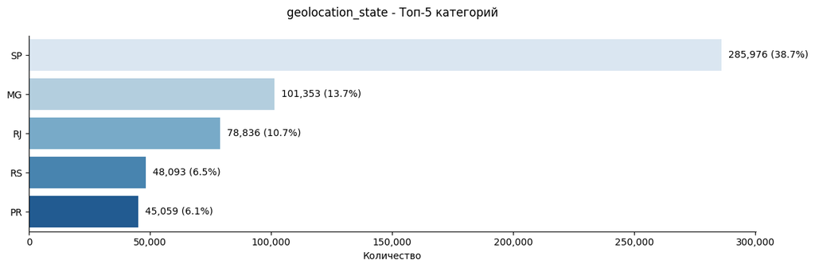

```
+-------------------------+------------+
| Метрика                 | Значение   |
+=========================+============+
| Всего записей:          | 738,332    |
+-------------------------+------------+
| Уникальных значений:    | 27         |
+-------------------------+------------+
| Пропуски:               | 0 (0.0%)   |
+-------------------------+------------+
| Доминирующая категория: | SP (38.7%) |
+-------------------------+------------+


=============================================================================================================================
Анализ таблицы: MARKETING_QUALIFIED
=============================================================================================================================
```

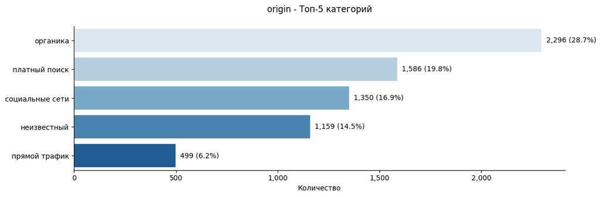

```
+-------------------------+------------------+
| Метрика                 | Значение         |
+=========================+==================+
| Всего записей:          | 8,000            |
+-------------------------+------------------+
| Уникальных значений:    | 10               |
+-------------------------+------------------+
| Пропуски:               | 0 (0.0%)         |
+-------------------------+------------------+
| Доминирующая категория: | органика (28.7%) |
+-------------------------+------------------+


=============================================================================================================================
Анализ таблицы: ORDERS
=============================================================================================================================
```

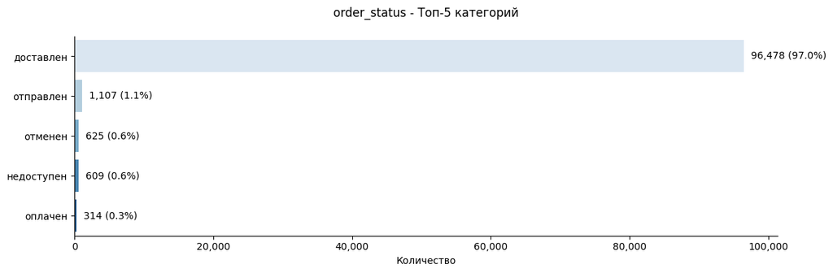

```
+-------------------------+-------------------+
| Метрика                 | Значение          |
+=========================+===================+
| Всего записей:          | 99,441            |
+-------------------------+-------------------+
| Уникальных значений:    | 8                 |
+-------------------------+-------------------+
| Пропуски:               | 0 (0.0%)          |
+-------------------------+-------------------+
| Доминирующая категория: | доставлен (97.0%) |
+-------------------------+-------------------+


=============================================================================================================================
Анализ таблицы: ORDER_ITEMS
=============================================================================================================================
```

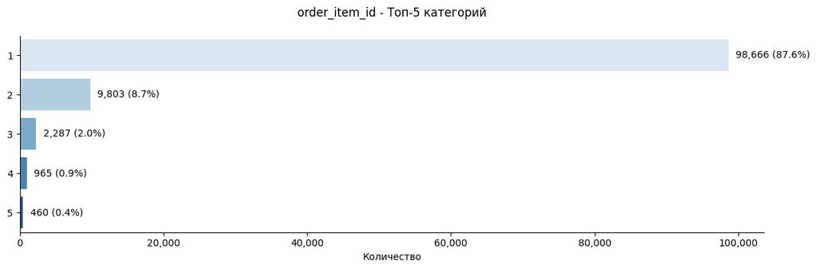

```
+-------------------------+------------+
| Метрика                 | Значение   |
+=========================+============+
| Всего записей:          | 112,650    |
+-------------------------+------------+
| Уникальных значений:    | 21         |
+-------------------------+------------+
| Пропуски:               | 0 (0.0%)   |
+-------------------------+------------+
| Доминирующая категория: | 1 (87.6%)  |
+-------------------------+------------+


=============================================================================================================================
Анализ таблицы: ORDER_PAYMENTS
=============================================================================================================================
```

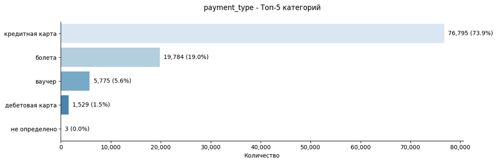

```
+-------------------------+-------------------------+
| Метрика                 | Значение                |
+=========================+=========================+
| Всего записей:          | 103,886                 |
+-------------------------+-------------------------+
| Уникальных значений:    | 5                       |
+-------------------------+-------------------------+
| Пропуски:               | 0 (0.0%)                |
+-------------------------+-------------------------+
| Доминирующая категория: | кредитная карта (73.9%) |
+-------------------------+-------------------------+


------------------------------------------------------------
В таблице ORDER_REVIEWS нет категориальных признаков
------------------------------------------------------------

=============================================================================================================================
Анализ таблицы: PRODUCTS
=============================================================================================================================
```

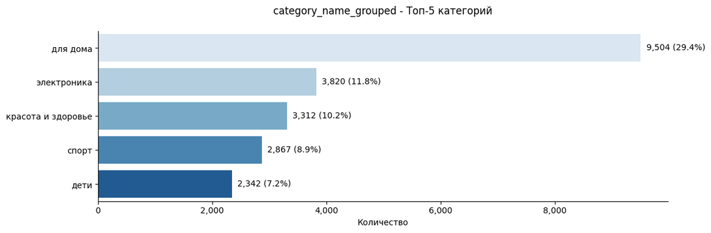

```
+-------------------------+------------------+
| Метрика                 | Значение         |
+=========================+==================+
| Всего записей:          | 32,328           |
+-------------------------+------------------+
| Уникальных значений:    | 20               |
+-------------------------+------------------+
| Пропуски:               | 0 (0.0%)         |
+-------------------------+------------------+
| Доминирующая категория: | для дома (29.4%) |
+-------------------------+------------------+


=============================================================================================================================
Анализ таблицы: SELLERS
=============================================================================================================================
```

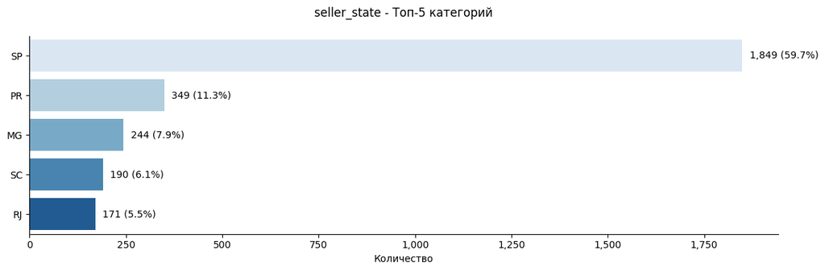

```
+-------------------------+------------+
| Метрика                 | Значение   |
+=========================+============+
| Всего записей:          | 3,095      |
+-------------------------+------------+
| Уникальных значений:    | 23         |
+-------------------------+------------+
| Пропуски:               | 0 (0.0%)   |
+-------------------------+------------+
| Доминирующая категория: | SP (59.7%) |
+-------------------------+------------+


✅ Анализ категориальных признаков завершен!
```

```python
from src.categorical_features import analyze_categorical_features
report = analyze_categorical_features(
    df_dict=dfso,
    top_n=5,
    max_cardinality=30,
    palette='Blues',
    exclude_tables=[''],
    exclude_columns=['sr_id', 'session_id']
)
```

### Временные ряды.

```
=============================================================================================================================
Анализ таблицы: CLOSED_DEALS
=============================================================================================================================
📅 Временной диапазон для 'won_date':
   Начало: 2017-12-05 02:00:00
   Конец:  2018-11-14 18:04:19
🔍 Обнаружены пропуски: 49 периодов.
→ Тренд: 📉 Падение (наклон = -0.06)
```

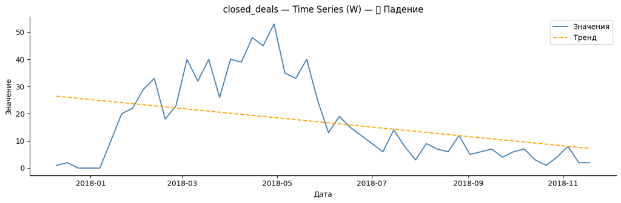

```
📝 Автокомментарии:
 - ⚠️ Данные показывают колебания, возможна сезонность или нестабильность.
 - ⚠️ Обнаружены пропуски данных в 49 периодах.

=============================================================================================================================
Анализ таблицы: MARKETING_QUALIFIED
=============================================================================================================================
📅 Временной диапазон для 'first_contact_date':
   Начало: 2017-06-14 00:00:00
   Конец:  2018-05-31 00:00:00
🔍 Обнаружены пропуски: 0 периодов.
→ Тренд: 📈 Рост (наклон = 0.90)
```

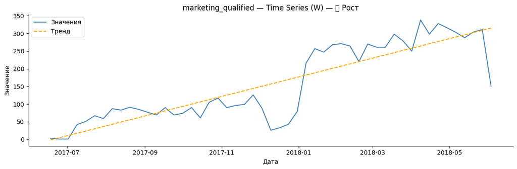

```
📝 Автокомментарии:
 - ⚠️ Данные показывают колебания, возможна сезонность или нестабильность.

=============================================================================================================================
Анализ таблицы: ORDERS
=============================================================================================================================
📅 Временной диапазон для 'order_purchase_timestamp':
   Начало: 2016-09-04 21:15:19
   Конец:  2018-10-17 17:30:18
🔍 Обнаружены пропуски: 110 периодов.
→ Тренд: 📈 Рост (наклон = 1.69)
```

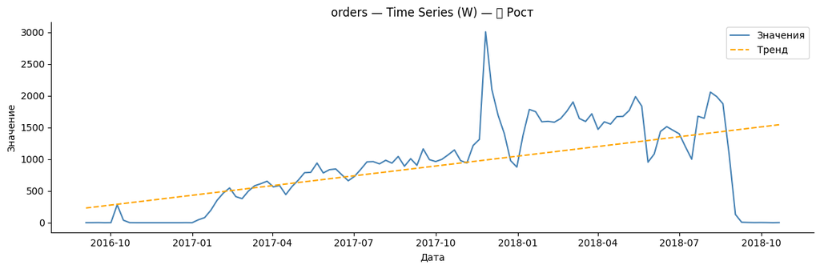

```
📝 Автокомментарии:
 - ⚠️ Данные показывают колебания, возможна сезонность или нестабильность.
 - ⚠️ Обнаружены пропуски данных в 110 периодах.

=============================================================================================================================
Анализ таблицы: ORDER_ITEMS
=============================================================================================================================
📅 Временной диапазон для 'shipping_limit_date':
   Начало: 2016-09-19 00:15:34
   Конец:  2020-04-09 22:35:08
🔍 Обнаружены пропуски: 185 периодов.
→ Тренд: 📉 Падение (наклон = -0.75)
```

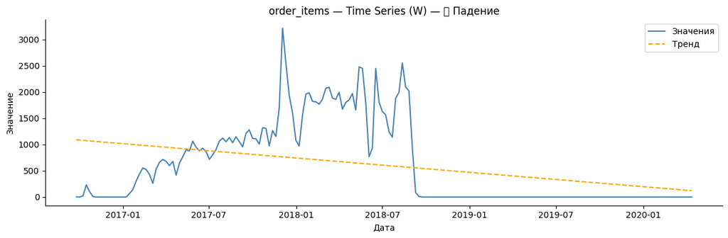

```
📝 Автокомментарии:
 - ⚠️ Данные показывают колебания, возможна сезонность или нестабильность.
 - ⚠️ Обнаружена сезонность, различия между месяцами значимы.
 - ⚠️ Обнаружены пропуски данных в 185 периодах.

=============================================================================================================================
Анализ таблицы: ORDER_REVIEWS
=============================================================================================================================
📅 Временной диапазон для 'review_creation_date':
   Начало: 2016-10-02 00:00:00
   Конец:  2018-08-31 00:00:00
🔍 Обнаружены пропуски: 0 периодов.
→ Тренд: 📈 Рост (наклон = 2.85)
```

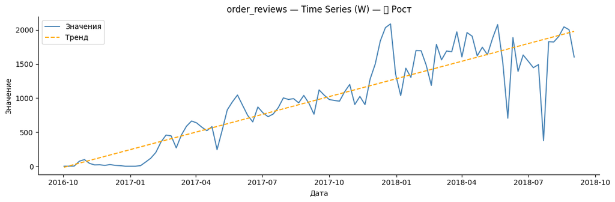

```
📝 Автокомментарии:
 - ⚠️ Данные показывают колебания, возможна сезонность или нестабильность.

✅ Анализ временных рядов завершен!
```

```python
from src.time_features import time_series_eda
time_series_eda(dfso, time_freq='W', save_plots=False)
```